# QUESTÕES UNIFICADAS

## QUESTÃO QU4

A eutrofização das águas é propiciada pelo incremento de nutrientes no corpo d’água, levando ao crescimento excessivo das plantas aquáticas, com consequente desequilíbrio do ecossistema aquático e progressiva degeneração da qualidade da água dos corpos d’água. A eutrofização, inicialmente, pode ocorrer de forma natural em ecossistemas aquáticos, todavia o estado trófico de lagos tem sido alterado principalmente pelo influxo de nutrientes provenientes do despejo de esgotos urbanos e industriais.

A avaliação de parâmetros de qualidade das águas de um rio pode permitir a análise de seu estado de eutrofização, sendo a clorofila um dos principais parâmetros de qualidade avaliados. O índice de eutrofização (IET), proposto pela CETESB, é utilizado para avaliar-se a eutrofização de corpos d’água. Nesse índice, usualmente, é considerado o fósforo como o agente principal causador da eutrofização e a clorofila deve ser considerada como uma medida da resposta do corpo hídrico ao agente causador. Assim, o índice médio engloba, de forma simplória, a causa e o efeito do processo, utilizando-se a média nos meses em que estejam disponíveis dados de ambas variáveis, conforme observado nas faixas de trofia do Quadro 1.

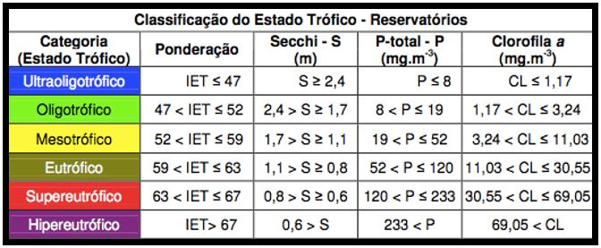

Quadro 1: Níveis Tróficos. Fonte: (CETESB, 2004)

Sólidos totais, turbidez, fósforo total, nitrogênio amoniacal, nitrogênio total, nitrato e clorofila A de um determinado rio em São Paulo foram levantados em seis pontos de amostragem (ver Figura 1) em dois períodos seco e úmido. Para estimativa do IET, utilizou-se dados históricos levantados no ponto 6. Com base no Quadro 1 e Figuras 1 a 7, conclua sobre a condição de eutrofização do rio X. Considere o ponto 6 como ponto de interesse na análise da eutrofização.

[figure not shown]

Figura 1: Pontos de monitoramento

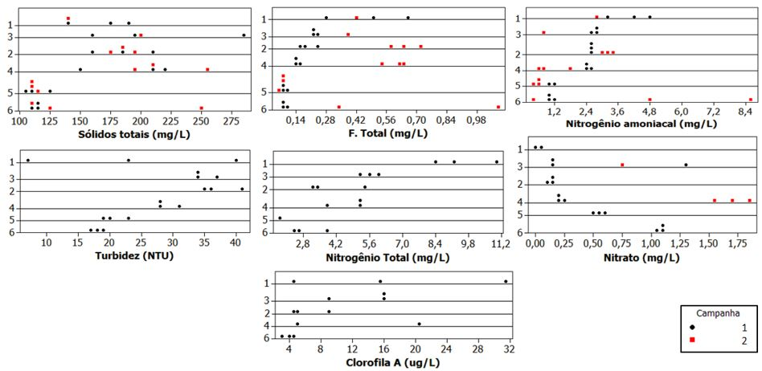

Figura 2: Dotplot dos principais parâmetros monitorados nas épocas úmida (1) e seca (2).

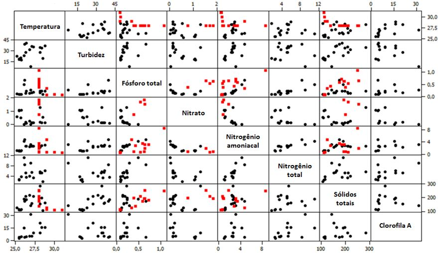

Figura 3: Matriz de correlação considerando o conjunto total de dados (época seca + úmida).

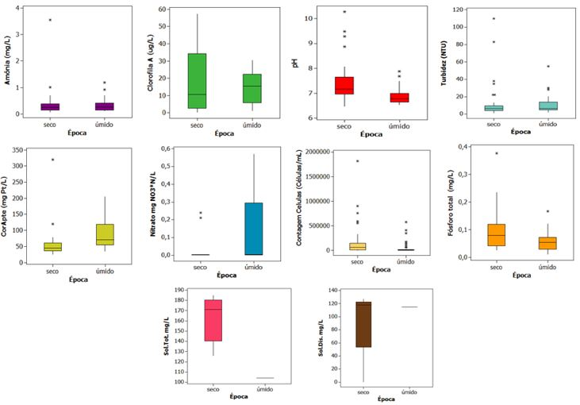

Figura 4: Boxplot considerando o conjunto total de dados (época seca + úmida) no ponto 6.

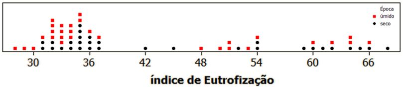

Figura 5: Dot plot do IET considerando o conjunto total de dados (época seca + úmida) no ponto 6.

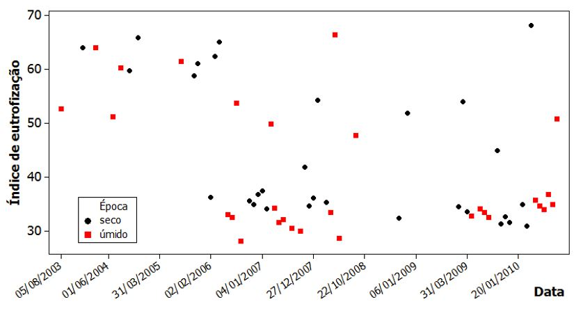

Figura 6: Série histórica do índice de eutrofização considerando o conjunto total de dados (época seca + úmida) no ponto 6.

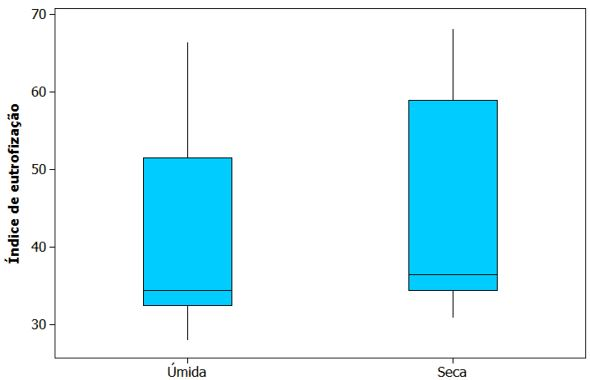

Figura 7: Boxplot do IET considerando o conjunto total de dados (época seca + úmida).

1. Considerando novos dados de monitoramento levantados para o ano de 2012 apresentados no Quadro 2:

| Epoca | Clorofila | Celulas | Turbidez | Fosforo | pH | DBO5 | OD | IET |
| --- | --- | --- | --- | --- | --- | --- | --- | --- |
| umido | 1.09200 | 381.89 | 7.5 | 0.020 | 6.68 | 1.24 | 4.9 | 47.2 |
| seco | 0.18200 | 6592.43 | 2.0 | 0.040 | 7.16 | 1.63 | 5.7 | 47.6 |
| umido | 4.52871 | 80.00 | 4.7 | 0.010 | 6.95 | 1.92 | 7.6 | 48.4 |
| seco | 1.45600 | 266.97 | 3.1 | 0.030 | 6.90 | 1.02 | 5.5 | 48.6 |
| umido | 1.96239 | 407094.02 | 4.6 | 0.012 | 6.94 | 1.70 | 6.9 | 49.5 |
| umido | 1.82000 | 116.69 | 55.0 | 0.010 | 6.63 | 1.56 | 5.0 | 49.7 |
| umido | 3.74485 | 7724.83 | 6.1 | 0.018 | 6.64 | 1.90 | 5.5 | 52.0 |
| seco | 1.09200 | 139102.56 | 13.0 | 0.042 | 6.84 | 2.70 | 5.3 | 52.1 |
| umido | 6.56945 | 436.70 | 6.0 | 0.022 | 7.48 | 3.80 | 8.8 | 53.2 |
| seco | 8.36881 | 7017.49 | NA | 0.025 | 4.60 | 4.00 | 4.2 | 54.0 |
| seco | 9.96400 | 2357.89 | NA | 0.028 | NA | 2.00 | 5.1 | 54.7 |
| seco | 5.09600 | 277.58 | 4.9 | NA | 7.10 | 2.06 | 4.4 | 54.7 |
| umido | 11.39670 | 3657.11 | 3.2 | 0.031 | 6.65 | 3.05 | 5.7 | 55.3 |
| seco | 11.39670 | 92735.04 | NA | 0.031 | 2.30 | 1.00 | 5.7 | 55.3 |
| seco | 6.18800 | 492.39 | 3.5 | NA | 7.16 | 1.00 | 5.8 | 55.7 |
| seco | 2.54800 | 6301.59 | 3.3 | 0.077 | 7.70 | 2.20 | 5.4 | 56.0 |
| umido | 6.91600 | 203.32 | 4.5 | NA | 6.82 | 1.31 | 3.7 | 56.2 |
| umido | 13.88710 | 6417.84 | 3.5 | 0.037 | 6.58 | 3.80 | 5.1 | 56.3 |
| umido | 20.20000 | 144871.79 | 5.4 | 0.018 | 7.88 | 4.00 | 6.4 | 56.7 |
| seco | 14.98450 | 60.00 | NA | 0.040 | 7.80 | 3.00 | 7.9 | 56.8 |
| seco | 8.00800 | 53.04 | 2.7 | 0.020 | 7.15 | 1.33 | 5.5 | 56.9 |
| umido | 15.33210 | 68.51 | 15.0 | 0.041 | 6.55 | 1.88 | 4.7 | 57.0 |
| umido | 15.33210 | 1971.32 | NA | 0.041 | 6.90 | 4.00 | 5.0 | 57.0 |
| seco | 16.32610 | 2012.00 | NA | 0.044 | 6.98 | 3.00 | 5.9 | 57.4 |
| umido | 8.91800 | 4650.00 | 20.0 | 0.060 | 6.66 | 1.42 | 4.5 | 57.5 |
| umido | 16.64240 | 68461.54 | NA | 0.045 | 7.02 | 2.50 | 7.3 | 57.5 |
| umido | 18.12540 | 576923.08 | 28.0 | 0.050 | 6.76 | 4.05 | 8.3 | 58.2 |
| seco | 10.56000 | 7917.55 | 6.1 | 0.030 | 6.96 | 1.57 | 5.8 | 58.3 |
| umido | 19.72060 | 609.96 | 8.7 | 0.056 | 7.07 | 1.00 | 4.4 | 58.9 |
| umido | 19.96970 | 348974.36 | 9.3 | 0.057 | 6.88 | 3.00 | 6.5 | 59.0 |
| seco | 20.21450 | 43376.07 | NA | 0.058 | 7.00 | 4.00 | 5.8 | 59.1 |
| umido | 22.03330 | 468.52 | NA | 0.066 | 7.00 | 3.00 | 3.4 | 59.9 |
| umido | 14.56000 | 564.00 | 5.8 | 0.050 | 7.03 | 1.09 | 5.8 | 59.9 |
| seco | 14.74000 | 2853.55 | 8.6 | 0.080 | 7.64 | 2.12 | 7.6 | 59.9 |
| seco | 23.06120 | 40341.88 | 8.4 | 0.071 | 7.69 | 4.12 | 6.5 | 60.3 |
| umido | 23.06120 | 461.01 | 9.7 | 0.071 | 8.50 | 1.00 | 4.1 | 60.3 |
| umido | 16.20000 | 12050.69 | 20.0 | 0.060 | 6.84 | 2.29 | 3.9 | 60.4 |
| umido | 23.83270 | 3383.95 | 5.6 | 0.075 | 6.57 | 1.69 | 3.3 | 60.6 |
| umido | 21.66000 | 168547.01 | 6.3 | 0.062 | 7.27 | 3.25 | 5.6 | 60.6 |
| seco | 18.38000 | 72505.68 | 5.7 | 0.030 | 7.17 | 2.46 | 7.5 | 61.0 |
| seco | 24.74110 | 100427.35 | 35.0 | 0.080 | 9.80 | 3.80 | 7.0 | 61.0 |
| seco | 25.08870 | 1814957.30 | 83.0 | 0.082 | 10.30 | 7.10 | 8.7 | 61.2 |
| umido | 25.25930 | 835.38 | 3.7 | 0.083 | 4.50 | NA | 4.0 | 61.2 |
| umido | 30.39000 | 1311.41 | 4.4 | 0.066 | 6.77 | 2.70 | 5.7 | 61.7 |
| seco | 21.66000 | 16919.76 | 5.7 | 0.080 | 7.52 | 1.78 | 4.9 | 61.8 |
| seco | 26.86050 | 150.28 | 2.3 | 0.093 | 7.12 | 1.24 | 5.5 | 61.9 |
| seco | 26.86050 | 8904.09 | 6.8 | 0.093 | 3.70 | NA | 5.8 | 61.9 |
| umido | 26.86050 | 645.32 | 6.9 | 0.093 | 7.60 | NA | 4.4 | 61.9 |
| umido | 24.21000 | 139743.59 | 7.7 | 0.009 | 6.98 | 1.80 | 6.1 | 62.4 |
| seco | 28.56880 | 320662.39 | 7.9 | 0.105 | 6.80 | 3.60 | 4.0 | 62.7 |
| seco | 45.50000 | 109401.71 | 9.1 | 0.073 | 6.98 | 5.00 | 3.9 | 63.0 |
| seco | 29.72630 | 26858.97 | 22.0 | 0.114 | 6.90 | 2.22 | 3.9 | 63.2 |
| umido | 30.44830 | 274.04 | 21.0 | 0.120 | 7.50 | 1.03 | 4.1 | 63.5 |
| seco | 34.22000 | 4923.88 | 6.2 | 0.150 | 7.45 | 5.10 | 5.3 | 64.1 |
| seco | 32.00160 | 553162.39 | 38.0 | 0.134 | 9.49 | 11.20 | 5.2 | 64.1 |
| seco | 32.61810 | 1002.46 | 8.1 | 0.140 | 7.42 | 1.75 | 7.3 | 64.4 |
| umido | 35.01590 | 402.22 | 8.3 | 0.166 | 6.50 | 9.80 | 4.2 | 65.4 |
| seco | 35.18440 | 57.46 | 7.1 | 0.168 | 7.12 | 1.39 | 6.7 | 65.5 |
| seco | 57.15000 | 588547.01 | 110.0 | 0.235 | 8.87 | 5.60 | 2.2 | 67.1 |
| seco | 38.04000 | 500000.00 | 9.2 | 0.376 | 9.28 | 7.10 | 5.9 | 67.5 |

| Variavel | Clorofila.seco | Clorofila.umido | Fosfato.seco | Fosfato.umido | IET.seco | IET.umido |
| --- | --- | --- | --- | --- | --- | --- |
| N | 29.00 | 27.00 | 40.00000 | 39.00000 | 35.000 | 32.000 |
| Media | 17.66 | 14.60 | 0.02000 | 0.03750 | 59.279 | 57.488 |
| DP | 18.03 | 9.79 | 0.01483 | 0.02121 | 4.964 | 4.618 |
| Q1 | 2.55 | 5.64 | 0.01000 | 0.02000 | 55.667 | 55.742 |
| Mediana | 10.56 | 15.38 | 0.02000 | 0.03000 | 60.293 | 58.168 |
| Q3 | 34.22 | 22.30 | 0.02000 | 0.06250 | 62.958 | 60.634 |

a.1.) Compare se há mudanças no estado de eutrofização do rio para os períodos seco e úmido considerando a avaliação de intervalos de confiança do IET e nível de significância de 10%.

a.2. Com base na teoria do teste de hipóteses, verifique, se possível, se o comportamento das amostras no período seco e úmido encontrado para o IET também é verificado para a clorofila e fosfato.

2. Considerando os dados apresentados no Quadro 2:

b.1. Qual a probabilidade de uma amostra selecionada ao acaso apresentar valores de IET na faixa trófica.

b.2. Uma análise específica será realizada considerando dados com maior probabilidade de ocorrência. Qual o valor limite de IET caso deseje-se considerar nesta análise dados com probabilidade superior a 80%?

### Resposta letra a)

#### Resposta letra a.1)